# Bouncer Tracker Preliminary Exploratory Data Analysis

2020-06-24

# 1 Introduction

Welcome to a brief, preliminary overview of the data contained in Bouncer Tracker.

The aim of this analysis is two-fold: first, to establish the coding chunks necesssary to conduct a more thorough analysis at a later date. Second, to begin parsing and analyzing data to the end of discovering trends.

Questions examined include:

Answering these questions might help us better anticipate the need for bouncers per event type, size, duration, and start time.

Importantly, the data frame titled ‘Bouncer Tracker’ is incomplete – that is, it lacks crucial data to conduct a truly meaningful analysis to the end of discovering actionable insights and answering the questions above.

As such, the aim of this analysis was also to help us better understand the kind of data we might need in order to provide better insights and action plans to interested parties.

Having completed the introductory remarks to this overview, let’s turn to data analysis.

What follows is:

- tidying of the data and feature engineering.
- data visualization of descriptive statistics.
- analysis of data for trends.

# 2 Tidying the Data and Introducing Requisite Libraries

```r
# Load Libraries
library(lubridate)
library(tidyverse)
library(car)

#Read in Data
train = read.csv("Bouncer.Tracker6.csv")
```

# 3 Data Tidying

Below is a small snippet of code that speaks to the kind of data tidying completed prior to the construction of this Markdown document. Much of the tidying (recoding variables, numericizing variables, etc.) was completed elsewhere, and neither useful nor instructive for the purposes of this analysis. Accordingly, only a small snippet is provided, along with a glimpse of the data.

The glimpse() function, contained in the tidyverse (a library of functions in R), offers analysts a general overview of a given data frame’s structure.

```r
# Let us tidy! And also get a glimpse.
train = train %>%
  mutate(date=as.Date(date),
         event.name=as.character(event.name),
         start.time=as.Date(start.time),
         end.time=as.Date(end.time),
         notes=as.character(notes),
         day=as.Date(day),
         multiple_bouncers=as.factor(multiple_bouncers))
glimpse(train)
```

```
## Observations: 56
## Variables: 20
## $ X                               <int> 1, 2, 3, 4, 5, 6, 7, 8, 9, 10, 1…
## $ date                            <date> 2020-06-20, 2020-06-18, 2020-06…
## $ event.name                      <chr> "US Open Classics: Henin v. Capr…
## $ start.time                      <date> 2020-06-20, 2020-06-18, 2020-06…
## $ end.time                        <date> 2020-06-20, 2020-06-18, 2020-06…
## $ bouncers                        <fct> "Kam", "Kam", "Abe", "Casey", "J…
## $ monitored                       <int> 4, 108, 60, 5, 13, 5, 7, 16, 15,…
## $ kicked                          <int> 0, 0, 0, 1, 0, 0, 1, 1, 0, 0, 1,…
## $ total.users                     <int> 0, 607, 391, 0, 877, 417, 509, 8…
## $ notes                           <chr> "No unusual activity reported.",…
## $ event.categories                <fct> sports, aquarium/museum, music/p…
## $ proportion_kicked_from_total    <dbl> 0.00000000, 0.00000000, 0.000000…
## $ proportion_monitored_from_total <dbl> 0.0000000, 17.7924217, 15.345268…
## $ duration                        <int> 13500, 9000, 6300, 10800, 12600,…
## $ day                             <date> 2020-06-20, 2020-06-18, 2020-06…
## $ multiple_bouncers               <fct> 0, 0, 0, 0, 0, 1, 1, 0, 1, 0, 1,…
## $ start.time.hour                 <int> 12, 11, 13, 16, 12, 15, 8, 13, 1…
## $ end.time.hour                   <int> 16, 14, 15, 19, 16, 17, 10, 17, …
## $ start.time.late                 <fct> Late, Late, Early, Early, Late, …
## $ end.time.late                   <fct> Early, Early, Early, Early, Earl…
```

# 4 Feature Engineering

Again, much of the coding necessary for the feature engineering completed for this preliminary analysis is not germaine to this report. Accordingly, a brief list of the features engineered should suffice.

The features summarized below were designed to the end of improving predictive power, and facilitating the discovery of latent trends in the data frame.

- multiple_bouncers: whether one or many bouncers were used for the events.
- event duration: length of event in seconds.
- porportion_kicked_from_total: percentage of kicked attendees.
- porpotion_monitored_from_total: percentage of monitored attendees.
- event.categories: events were partitioned into three main categories (sports, music/public events, and museum/aquarium).

# 5 First Visualizations

Below are a few visualizations that provide a general overview of the data’s structure. They offer what might be considered a fingertip feel for the data. All can be categorized as decriptive statistics. For signficance testing, please view below.

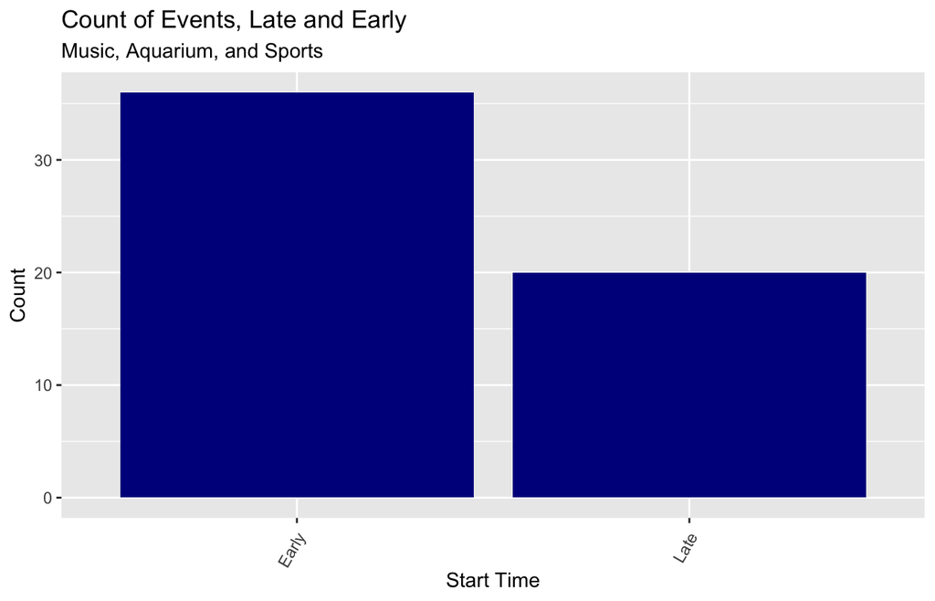

# 6 Continued Visualizations

Below are a few graphs that plot an event’s start time and end time, as they times relate to the number of attendees monitored and kicked.

Our line of thinking in engineering this feature is that later events will likely result in more attendeeds being monitored or kicked, particulary at events where alcohol is typically consumed.

At first glance, the trends lines indicate that this line of inquiry is likely uninstructive, as the trend lines seem consistent with the mean.

For example, we might consider used a mixed linear model approach in modelling our data in order to account for group effects with respect to event category. If we plan to use a machine learning approach, it is generally thought that the more features we have for our learning algorithm, the better.

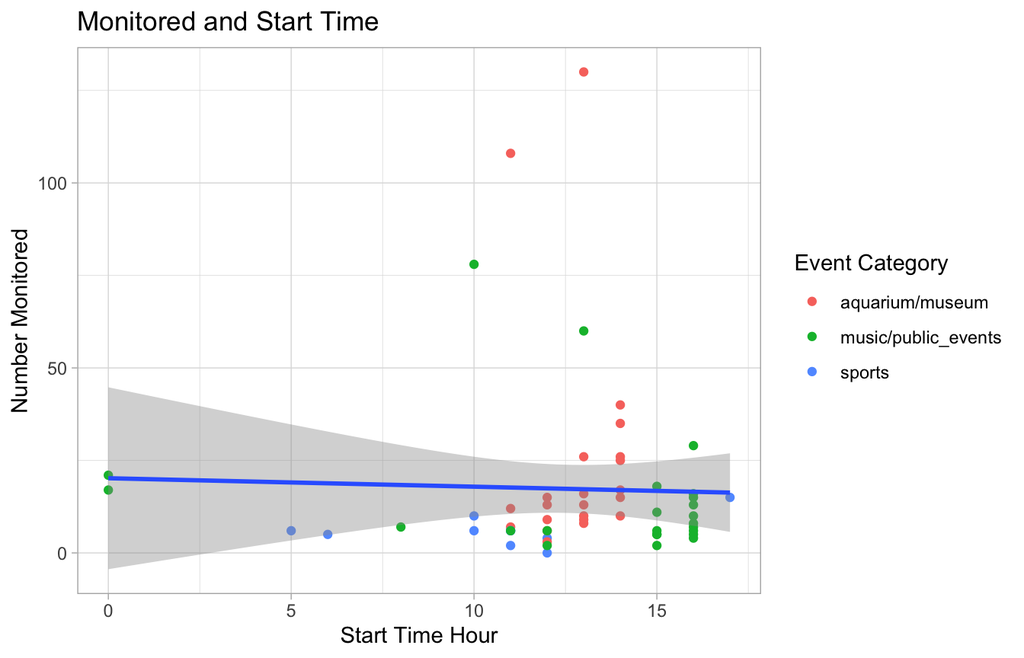

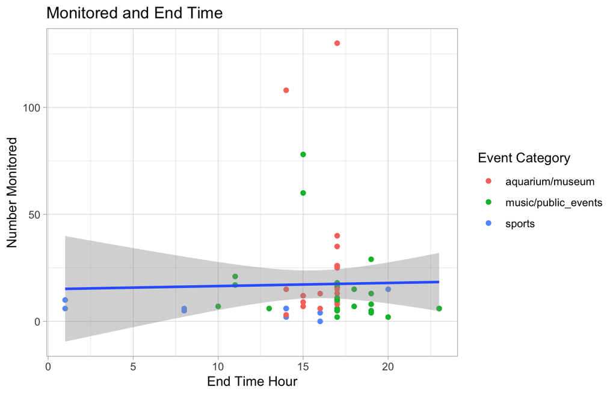

# 7 Continued Visualizations

Below are data visualizations with split plots, as an example of the kind of exploratory analysis conducted for this report. Importantly, the sample sizes are somewhat too small to make meaningful conclusions at this stage; further, trends lines are generally more instructive for continuous data, and if we are examining kicked or not kicked, we’re dealing with a classification problem. Nonetheless, the plots offer a point of depature for further analysis. (Here, more data would be useful.)

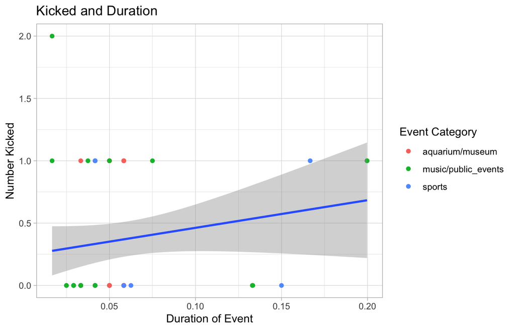

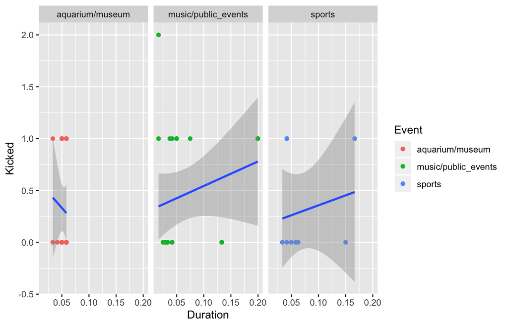

# 8 Significance Testing

Below are the results from a few very preliminary analyses. Linear models were used to examine relationships between new features and the rate at which individuals were monitored and kicked. Again, below is the result of one analysis from many.

Important to note is that the resultant analysis is simple in the extreme: it employs linear regression.

As is well known, simple models are generally the most interpretable, but the in this case, the analysis would strike some analysts as so simple as to seem trivial.

Nonetheless, it facilitates the development of a fingertip feel for the data set in terms of relationships between variables.

Here, we see the relation between event category, duration of the given event, and the significance tests sheds light on whether an event, due to its category and duration, results in a relative increase in the number of attendees ejected.

Though not published in this report, elsehwere, conducted similar regression analysis, we find that bouncer is a significant predictor of the rate at which attendees are kicked. In other words, the bouncer working an event explains much of the variance in the data, with respect to attendees kicked and monitored.

This observation, the only useful observation at this point, points us a way forward, for lack of a better turn of phrase. It would make sense to conduct a careful analysis of bouncer as it relates to rate of being kicked and, due to the relatively sparsity of the data set, request additional information about the bouncers.

```
##
## Call:
## lm(formula = kicked ~ duration + event.categories, data = duration_and_kicked_and_categories)
##
## Residuals:
##     Min      1Q  Median      3Q     Max
## -0.6089 -0.3730 -0.3042  0.5726  1.6451
##
## Coefficients:
##                   Estimate Std. Error t value Pr(>|t|)
## (Intercept)        0.22321    0.12620   1.769   0.0828 .
## duration           2.17724    1.62093   1.343   0.1850
## event.categories1 -0.01884    0.10085  -0.187   0.8525
## event.categories2  0.09537    0.09782   0.975   0.3341
## ---
## Signif. codes:  0 '***' 0.001 '**' 0.01 '*' 0.05 '.' 0.1 ' ' 1
##
## Residual standard error: 0.525 on 52 degrees of freedom
## Multiple R-squared:  0.05231,    Adjusted R-squared:  -0.002359
## F-statistic: 0.9569 on 3 and 52 DF,  p-value: 0.4201
```

```
## [1] 0.05231495
```

```
##
## =================================================
##                          Dependent variable:
##                     -----------------------------
##                                kicked
## -------------------------------------------------
## duration                        2.177
##                                (1.621)
##
## event.categories1              -0.019
##                                (0.101)
##
## event.categories2               0.095
##                                (0.098)
##
## Constant                        0.223
##                                (0.126)
##
## -------------------------------------------------
## Observations                     56
## R2                              0.052
## Adjusted R2                    -0.002
## Residual Std. Error        0.525 (df = 52)
## F Statistic              0.957 (df = 3; 52)
## =================================================
## Note:               *p<0.05; **p<0.01; ***p<0.001
```